# Makemore: Part I

```python
import numpy as np
import torch
import matplotlib.pyplot as plt
```

```python
words = open('../../data/names.txt').read().splitlines()
```

```python
words[:5]
```

```
['emma', 'olivia', 'ava', 'isabella', 'sophia']
```

```python
len(words)
```

```
32033
```

```python
min(len(w) for w in words)
```

```
2
```

```python
max(len(w) for w in words)
```

```
15
```

```python
for w in words[:1]:
    # two lists of characters, one with all the chars of a given word w,
    # one starting at the second character of each word w[1:]
    for ch1, ch2 in zip(w, w[1:]):
        print(ch1, ch2)
```

```
e m
m m
m a
```

```python
w
```

```
'emma'
```

```python
w[1:]
```

```
'mma'
```

```python
for w in words[:1]:
    # add special characters
    chs = ['<S>'] + list(w) + ['<E>']
    for ch1, ch2 in zip(chs, chs[1:]):
        print(ch1, ch2)
```

```
<S> e
e m
m m
m a
a <E>
```

```python
for w in words[:3]:
    # add special characters
    # create one list by appending 3 lists
    chs = ['<S>'] + list(w) + ['<E>']
    for ch1, ch2 in zip(chs, chs[1:]):
        print(ch1, ch2)
```

```
<S> e
e m
m m
m a
a <E>
<S> o
o l
l i
i v
v i
i a
a <E>
<S> a
a v
v a
a <E>
```

```python
# key: (ch1, ch2) | val: count
b: dict = {}

for w in words[:3]:
    # add special characters
    chs = ['<S>'] + list(w) + ['<E>']
    for ch1, ch2 in zip(chs, chs[1:]):
        # tuple made of two individual characters, e.g. (<S>, e)
        bigram = (ch1, ch2)
        # add up the bigrams and count
        # if the key doesn't exist in dict, it is created and initialized with a value of 0, + 1
        b[bigram] = b.get(bigram, 0) + 1
        print(ch1, ch2)
```

```
<S> e
e m
m m
m a
a <E>
<S> o
o l
l i
i v
v i
i a
a <E>
<S> a
a v
v a
a <E>
```

```python
b
```

```
{('<S>', 'e'): 1,
 ('e', 'm'): 1,
 ('m', 'm'): 1,
 ('m', 'a'): 1,
 ('a', '<E>'): 3,
 ('<S>', 'o'): 1,
 ('o', 'l'): 1,
 ('l', 'i'): 1,
 ('i', 'v'): 1,
 ('v', 'i'): 1,
 ('i', 'a'): 1,
 ('<S>', 'a'): 1,
 ('a', 'v'): 1,
 ('v', 'a'): 1}
```

```python
b = {}

for w in words:
    # add special characters
    chs = ['<S>'] + list(w) + ['<E>']
    for ch1, ch2 in zip(chs, chs[1:]):
        bigram = (ch1, ch2)
        # add up the bigrams and count
        b[bigram] = b.get(bigram, 0) + 1
```

```python
# counts across all the words of individual bigrams
b
```

```
{('<S>', 'e'): 1531,
 ('e', 'm'): 769,
 ('m', 'm'): 168,
 ('m', 'a'): 2590,
 ('a', '<E>'): 6640,
 ('<S>', 'o'): 394,
 ('o', 'l'): 619,
 ('l', 'i'): 2480,
 ('i', 'v'): 269,
 ('v', 'i'): 911,
 ('i', 'a'): 2445,
 ('<S>', 'a'): 4410,
 ('a', 'v'): 834,
 ('v', 'a'): 642,
 ('<S>', 'i'): 591,
 ('i', 's'): 1316,
 ('s', 'a'): 1201,
 ('a', 'b'): 541,
 ('b', 'e'): 655,
 ('e', 'l'): 3248,
 ('l', 'l'): 1345,
 ('l', 'a'): 2623,
 ('<S>', 's'): 2055,
 ('s', 'o'): 531,
 ('o', 'p'): 95,
 ('p', 'h'): 204,
 ('h', 'i'): 729,
 ('<S>', 'c'): 1542,
 ('c', 'h'): 664,
 ('h', 'a'): 2244,
 ('a', 'r'): 3264,
 ('r', 'l'): 413,
 ('l', 'o'): 692,
 ('o', 't'): 118,
 ('t', 't'): 374,
 ('t', 'e'): 716,
 ('e', '<E>'): 3983,
 ('<S>', 'm'): 2538,
 ('m', 'i'): 1256,
 ('a', 'm'): 1634,
```

[output cut: 572 more lines]

```
 ('v', 'h'): 1,
 ('k', 'v'): 2,
 ('h', 'h'): 1,
 ('s', 'g'): 2,
 ('g', 'v'): 1,
 ('d', 'q'): 1,
 ('x', 'b'): 1,
 ('w', 'z'): 1,
 ('h', 'q'): 1,
 ('j', 'b'): 1,
 ('z', 'd'): 2,
 ('x', 'm'): 1,
 ('w', 'g'): 1,
 ('t', 'b'): 1,
 ('z', 'x'): 1}
```

```python
# tuples of key (tuples of bigrams)-value(counts)
b.items()
```

```
dict_items([(('<S>', 'e'), 1531), (('e', 'm'), 769), (('m', 'm'), 168), (('m', 'a'), 2590), (('a', '<E>'), 6640), (('<S>', 'o'), 394), (('o', 'l'), 619), (('l', 'i'), 2480), (('i', 'v'), 269), (('v', 'i'), 911), (('i', 'a'), 2445), (('<S>', 'a'), 4410), (('a', 'v'), 834), (('v', 'a'), 642), (('<S>',…
```

```python
# sort by the count (x[1]), descending order
sorted(b.items(), key = lambda x: -x[1])
```

```
[(('n', '<E>'), 6763),
 (('a', '<E>'), 6640),
 (('a', 'n'), 5438),
 (('<S>', 'a'), 4410),
 (('e', '<E>'), 3983),
 (('a', 'r'), 3264),
 (('e', 'l'), 3248),
 (('r', 'i'), 3033),
 (('n', 'a'), 2977),
 (('<S>', 'k'), 2963),
 (('l', 'e'), 2921),
 (('e', 'n'), 2675),
 (('l', 'a'), 2623),
 (('m', 'a'), 2590),
 (('<S>', 'm'), 2538),
 (('a', 'l'), 2528),
 (('i', '<E>'), 2489),
 (('l', 'i'), 2480),
 (('i', 'a'), 2445),
 (('<S>', 'j'), 2422),
 (('o', 'n'), 2411),
 (('h', '<E>'), 2409),
 (('r', 'a'), 2356),
 (('a', 'h'), 2332),
 (('h', 'a'), 2244),
 (('y', 'a'), 2143),
 (('i', 'n'), 2126),
 (('<S>', 's'), 2055),
 (('a', 'y'), 2050),
 (('y', '<E>'), 2007),
 (('e', 'r'), 1958),
 (('n', 'n'), 1906),
 (('y', 'n'), 1826),
 (('k', 'a'), 1731),
 (('n', 'i'), 1725),
 (('r', 'e'), 1697),
 (('<S>', 'd'), 1690),
 (('i', 'e'), 1653),
 (('a', 'i'), 1650),
 (('<S>', 'r'), 1639),
```

[output cut: 572 more lines]

```
 (('g', 'z'), 1),
 (('v', 'd'), 1),
 (('d', 'b'), 1),
 (('v', 'h'), 1),
 (('h', 'h'), 1),
 (('g', 'v'), 1),
 (('d', 'q'), 1),
 (('x', 'b'), 1),
 (('w', 'z'), 1),
 (('h', 'q'), 1),
 (('j', 'b'), 1),
 (('x', 'm'), 1),
 (('w', 'g'), 1),
 (('t', 'b'), 1),
 (('z', 'x'), 1)]
```

## Change bigram storage

```python
# store in 2d array with 1st-char, 2nd-char
a = torch.zeros((3, 5), dtype=torch.int32)
a
```

```
tensor([[0, 0, 0, 0, 0],
        [0, 0, 0, 0, 0],
        [0, 0, 0, 0, 0]], dtype=torch.int32)
```

```python
a.dtype
```

```
torch.int32
```

```python
a[1, 3] = 1
a
```

```
tensor([[0, 0, 0, 0, 0],
        [0, 0, 0, 1, 0],
        [0, 0, 0, 0, 0]], dtype=torch.int32)
```

```python
a[0, 0] = 5
a
```

```
tensor([[5, 0, 0, 0, 0],
        [0, 0, 0, 1, 0],
        [0, 0, 0, 0, 0]], dtype=torch.int32)
```

```python
N = torch.zeros((28, 28), dtype=torch.int32)
```

```python
# set of all lower case characters
chars = sorted(list(set(''.join(words))))
assert len(chars) == 26
```

```python
stoi = {s:idx for idx,s in enumerate(chars)}
stoi
```

```
{'a': 0,
 'b': 1,
 'c': 2,
 'd': 3,
 'e': 4,
 'f': 5,
 'g': 6,
 'h': 7,
 'i': 8,
 'j': 9,
 'k': 10,
 'l': 11,
 'm': 12,
 'n': 13,
 'o': 14,
 'p': 15,
 'q': 16,
 'r': 17,
 's': 18,
 't': 19,
 'u': 20,
 'v': 21,
 'w': 22,
 'x': 23,
 'y': 24,
 'z': 25}
```

```python
stoi['<S>'] = 26
stoi['<E>'] = 27
stoi
```

```
{'a': 0,
 'b': 1,
 'c': 2,
 'd': 3,
 'e': 4,
 'f': 5,
 'g': 6,
 'h': 7,
 'i': 8,
 'j': 9,
 'k': 10,
 'l': 11,
 'm': 12,
 'n': 13,
 'o': 14,
 'p': 15,
 'q': 16,
 'r': 17,
 's': 18,
 't': 19,
 'u': 20,
 'v': 21,
 'w': 22,
 'x': 23,
 'y': 24,
 'z': 25,
 '<S>': 26,
 '<E>': 27}
```

```python
for w in words:
    # add special characters
    chs = ['<S>'] + list(w) + ['<E>']
    for ch1, ch2 in zip(chs, chs[1:]):
        ix1 = stoi[ch1]
        ix2 = stoi[ch2]

        N[ix1, ix2] += 1
```

```python
N
```

```
tensor([[ 556,  541,  470, 1042,  692,  134,  168, 2332, 1650,  175,  568, 2528,
         1634, 5438,   63,   82,   60, 3264, 1118,  687,  381,  834,  161,  182,
         2050,  435,    0, 6640],
        [ 321,   38,    1,   65,  655,    0,    0,   41,  217,    1,    0,  103,
            0,    4,  105,    0,    0,  842,    8,    2,   45,    0,    0,    0,
           83,    0,    0,  114],
        [ 815,    0,   42,    1,  551,    0,    2,  664,  271,    3,  316,  116,
            0,    0,  380,    1,   11,   76,    5,   35,   35,    0,    0,    3,
          104,    4,    0,   97],
        [1303,    1,    3,  149, 1283,    5,   25,  118,  674,    9,    3,   60,
           30,   31,  378,    0,    1,  424,   29,    4,   92,   17,   23,    0,
          317,    1,    0,  516],
        [ 679,  121,  153,  384, 1271,   82,  125,  152,  818,   55,  178, 3248,
          769, 2675,  269,   83,   14, 1958,  861,  580,   69,  463,   50,  132,
         1070,  181,    0, 3983],
```

[output cut: 69 more lines]

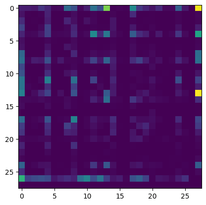

```python
%matplotlib inline
plt.imshow(N)
```

```python
itos = {i:s for s,i in stoi.items()}
itos
```

```
{0: 'a',
 1: 'b',
 2: 'c',
 3: 'd',
 4: 'e',
 5: 'f',
 6: 'g',
 7: 'h',
 8: 'i',
 9: 'j',
 10: 'k',
 11: 'l',
 12: 'm',
 13: 'n',
 14: 'o',
 15: 'p',
 16: 'q',
 17: 'r',
 18: 's',
 19: 't',
 20: 'u',
 21: 'v',
 22: 'w',
 23: 'x',
 24: 'y',
 25: 'z',
 26: '<S>',
 27: '<E>'}
```

```
(np.float64(-0.5), np.float64(27.5), np.float64(27.5), np.float64(-0.5))
```

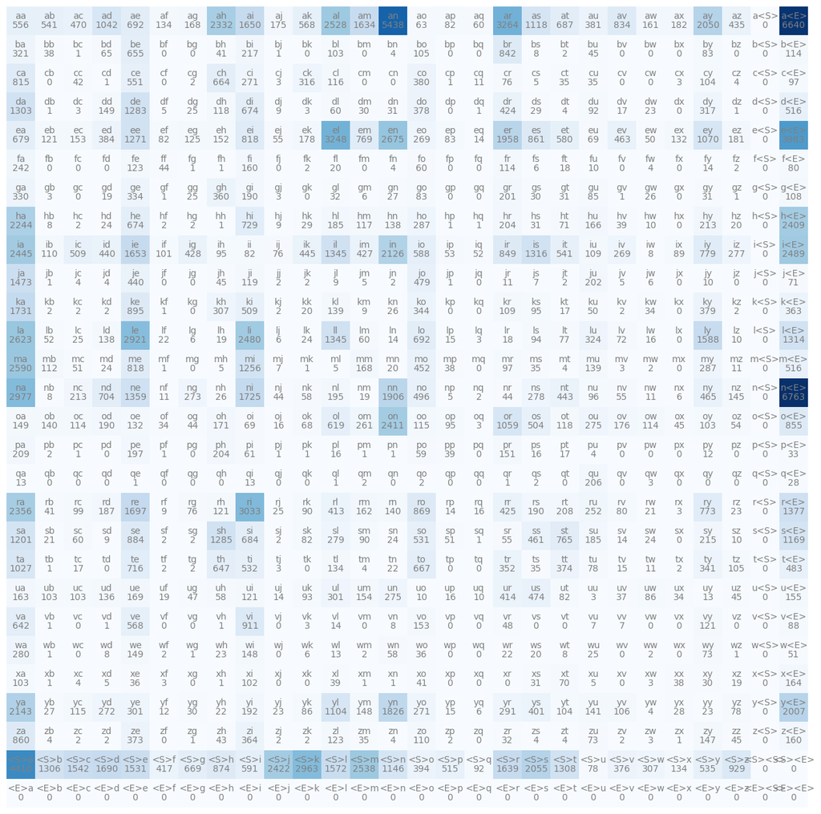

```python
plt.figure(figsize=(16, 16))
plt.imshow(N, cmap='Blues')

for i in range(28):
    for j in range(28):
        chstr = itos[i] + itos[j]
        plt.text(j, i, chstr, ha="center", va="bottom", color="gray")
        plt.text(j, i, N[i, j].item(), ha="center", va="top", color="gray")
plt.axis("off")
```

```python
N = torch.zeros((27, 27), dtype=torch.int32)
chars = sorted(list(set(''.join(words))))
assert len(chars) == 26
stoi = {s:idx + 1 for idx,s in enumerate(chars)}

# new special token
stoi['.'] = 0
itos = {i:s for s,i in stoi.items()}
```

```python
stoi
```

```
{'a': 1,
 'b': 2,
 'c': 3,
 'd': 4,
 'e': 5,
 'f': 6,
 'g': 7,
 'h': 8,
 'i': 9,
 'j': 10,
 'k': 11,
 'l': 12,
 'm': 13,
 'n': 14,
 'o': 15,
 'p': 16,
 'q': 17,
 'r': 18,
 's': 19,
 't': 20,
 'u': 21,
 'v': 22,
 'w': 23,
 'x': 24,
 'y': 25,
 'z': 26,
 '.': 0}
```

```python
itos
```

```
{1: 'a',
 2: 'b',
 3: 'c',
 4: 'd',
 5: 'e',
 6: 'f',
 7: 'g',
 8: 'h',
 9: 'i',
 10: 'j',
 11: 'k',
 12: 'l',
 13: 'm',
 14: 'n',
 15: 'o',
 16: 'p',
 17: 'q',
 18: 'r',
 19: 's',
 20: 't',
 21: 'u',
 22: 'v',
 23: 'w',
 24: 'x',
 25: 'y',
 26: 'z',
 0: '.'}
```

```python
for w in words:
    # add special characters
    chs = ['.'] + list(w) + ['.']
    for ch1, ch2 in zip(chs, chs[1:]):
        ix1 = stoi[ch1]
        ix2 = stoi[ch2]

        N[ix1, ix2] += 1
```

```
(np.float64(-0.5), np.float64(26.5), np.float64(26.5), np.float64(-0.5))
```

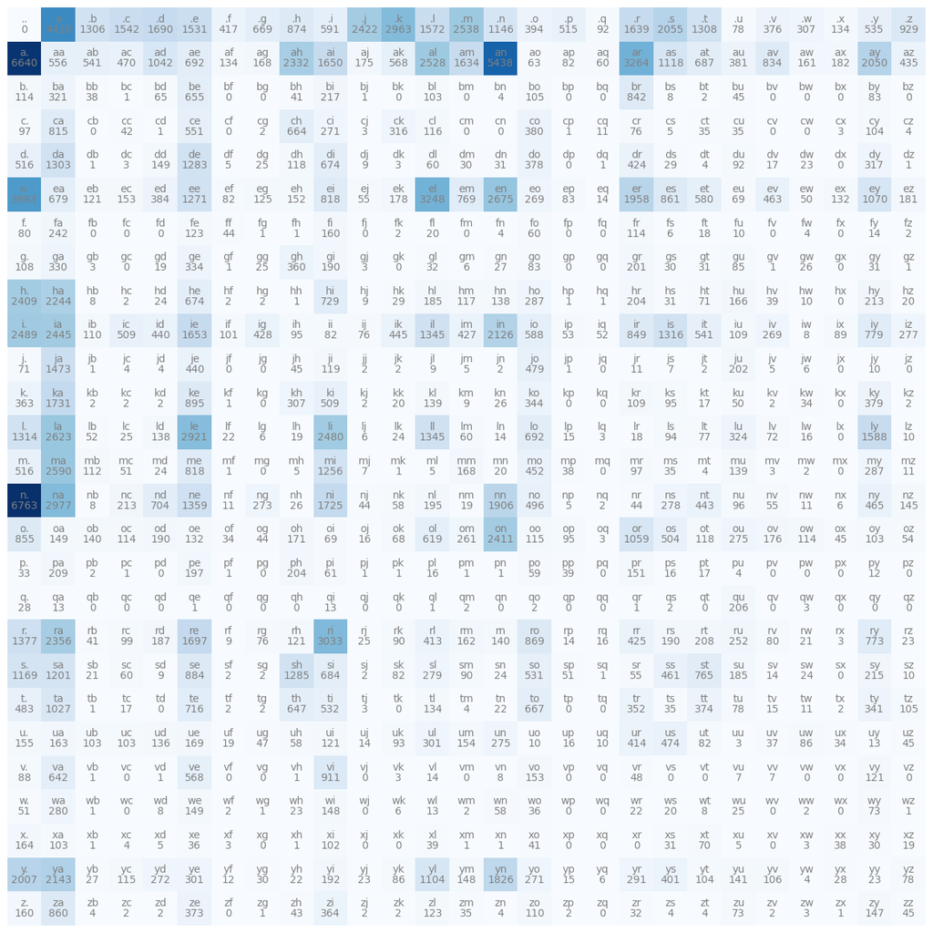

```python
plt.figure(figsize=(16, 16))
plt.imshow(N, cmap='Blues')

for i in range(27):
    for j in range(27):
        chstr = itos[i] + itos[j]
        plt.text(j, i, chstr, ha="center", va="bottom", color="gray")
        plt.text(j, i, N[i, j].item(), ha="center", va="top", color="gray")
plt.axis("off")
```

```python
N[0, :]
```

```
tensor([   0, 4410, 1306, 1542, 1690, 1531,  417,  669,  874,  591, 2422, 2963,
        1572, 2538, 1146,  394,  515,   92, 1639, 2055, 1308,   78,  376,  307,
         134,  535,  929], dtype=torch.int32)
```

```python
len(N[0])
```

```
27
```

## Sample from counts

```python
# create a probability vector
# floats are needed so that we can normalize the counts
p = N[0].float()
p = p / p.sum()
assert p.sum() == 1.0
p
```

```
tensor([0.0000, 0.1377, 0.0408, 0.0481, 0.0528, 0.0478, 0.0130, 0.0209, 0.0273,
        0.0184, 0.0756, 0.0925, 0.0491, 0.0792, 0.0358, 0.0123, 0.0161, 0.0029,
        0.0512, 0.0642, 0.0408, 0.0024, 0.0117, 0.0096, 0.0042, 0.0167, 0.0290])
```

```python
# seed a generator
g = torch.Generator().manual_seed(2147483647)

# create random numbers
p = torch.rand(3, generator=g)
p = p / p.sum()
p
assert p.sum() == 1.0
```

```python
# draw values from mutinomial distribution -> we get the indexes
torch.multinomial(p, num_samples=20, replacement=True, generator=g)
```

```
tensor([1, 1, 2, 0, 0, 2, 1, 1, 0, 0, 0, 1, 1, 0, 0, 1, 1, 0, 0, 1])
```

```python
g = torch.Generator().manual_seed(2147483647)

p = N[0].float()
p = p / p.sum()
assert p.sum() == 1.0

idx = torch.multinomial(p, num_samples=1, replacement=True, generator=g).item()
print(f'{idx} | {itos[idx]}')
```

```
10 | j
```

```python
# start token
idx = 0

# sample 20 names
for i in range(20):
    out = []
    while True:
        # grab the row corresponding to current idx
        p = N[idx].float()
        # in each row, we have the count of the 27 characters, associated with the start token '.'
        assert len(p) == 27
        #print(f'row: {p}')
        # normalize p to sum to 1 -> probabilities
        p = p/p.sum()
        #print(f'row norm: {p}')

        # next index is sampled -> returns the index of the sampled character
        idx = torch.multinomial(p, num_samples=1, replacement=True, generator=g).item()
        out.append(itos[idx])
        # when we reach the end token, stop the loop
        if idx == 0:
            break

    print(''.join(out))
```

```
sonde.
janasah.
p.
cony.
a.
nn.
kohin.
tolian.
juee.
ksahnaauranilevias.
dedainrwieta.
ssonielylarte.
faveumerifontume.
phynslenaruani.
core.
yaenon.
ka.
jabdinerimikimaynin.
anaasn.
ssorionsush.
```

### Output from an 'untrained' model (no bigram) where every char is sampled from uniform distribution

```python
# start token
idx = 0

# sample 20 names
for i in  range(20):
    out = []
    while True:
        # uniform distribution
        p = torch.ones(27) / 27

        # next index is sampled -> returns the index of the sampled character
        idx = torch.multinomial(p, num_samples=1, replacement=True, generator=g).item()
        out.append(itos[idx])
        # when we reach the end token, stop the loop
        if idx == 0:
            break

    print(''.join(out))
```

```
dgosfmptpagicz.
rjpiufmthdt.
rkrrsru.
iyumuyfy.
mjekujcbkhvupwyhvpvhvccragr.
wdkhwfdztta.
mplyisbxlyhuuiqzavmpocbzthqmimvyqwat.
f.
.
ndxjxfpvslqtikyzsaloevgvvnundewkfmbjzqegruxiteaxchwtmurzsodridcdznojvaliypvrghvxtezrwguciqqvywhqelv.
viosvhibdhnceukgmtmwboscnbzoiwupnwnpipixtewbgsgyewfdacbfcxrvjypkmsbranmjrdsydotafvkdkbdepihzpwzsqdab.
vfuolwbasrtugttbiqbujfdtskceqjtcdlcndfujqllsppgkltalmlokdmsl.
fddmxjv.
mfsgxmw.
vdihkvngtojvrdsyqivcob.
uziengogtjvnvqgfjtkqufrxfjlwglykiiluohgnoiuwzylq.
fsgircvmhtipagkxwvjypnsriadmfujnlkcicvatjvryzeljxkbrlrjsp.
puybxzhwuejbiotzqpxrkbhhhgsivfjblaklxoivwqjpdkucftazqgwslvrvqcqmbadayrgufbalqdoumwytowbzqzrvbddvlhqn.
kvhztsmltmpcxnikfn.
inzastwohtcyonakisemrtfxwwlsxihficdlxfkdxjljagkjmeifigffkmcnjylullxfvyyb.
```

```python
# matrix that has the probabilities
P = N.float()
P.shape
```

```
torch.Size([27, 27])
```

```python
# sum over the 1-st dimension (i.e. row) and keep the dim
# we sum each element in a row -> this gives one value
# go to next row, make the sum -> one value
# etc.
p_1 = P.sum(dim=1, keepdim=True)
# should be (27, 1)
p_1.shape
```

```
torch.Size([27, 1])
```

```python
# a column vector of counts
p_1
```

```
tensor([[32033.],
        [33885.],
        [ 2645.],
        [ 3532.],
        [ 5496.],
        [20423.],
        [  905.],
        [ 1927.],
        [ 7616.],
        [17701.],
        [ 2900.],
        [ 5040.],
        [13958.],
        [ 6642.],
        [18327.],
        [ 7934.],
        [ 1026.],
        [  272.],
        [12700.],
        [ 8106.],
        [ 5570.],
        [ 3135.],
        [ 2573.],
        [  929.],
        [  697.],
        [ 9776.],
        [ 2398.]])
```

```python
P = N.float()
# P has shape (27, 27)
# P.sum() has shape (27, 1)
# -> broadcasting : copy the column from P.sum() 27 times so that it can be used to divide P
P /= P.sum(dim=1, keepdim=True)
```

#### An explanation on the **keepdim** importance in **broadcasting**

P has shape (27, 27), and P.sum(dim=1, keepdim=True) has shape (27, 1).

With broadcasting, it is like P.sum(...) has shape (27, 27), and the column vector gets copied in each row.

However, without the keepdim=True, the shape of P.sum(dim=1) would be (27).

With broadcasting, we align the dims to the right. So this becomes (1, 27), a row vector. This is called the **silent** broadcasting.

This means we would be normalizing the columns instead of the rows! The sum would not be 1 !

```python
P_buggy = N.float()
P_buggy = P_buggy / P_buggy.sum(dim=1, keepdim=False)

# the sum is not 1 !
print(f'{P_buggy[0].sum()} <-- this is bugged')
assert torch.round(P_buggy[0].sum(), decimals=3) != torch.round(torch.tensor(1.), decimals=3)

# it is the first column that sums to 1 (or any column)
print(f'{P_buggy[:, 0].sum()} <-- this is 1.0')
```

```
7.022482872009277 <-- this is bugged
1.0 <-- this is 1.0
```

```python
len(P)
```

```
27
```

```python
for i in range(len(P)):
    assert torch.round(P[i].sum(), decimals=3) == torch.round(torch.tensor(1.), decimals=3)
```

```python
# start token
idx = 0

# sample 10 names
for i in  range(10):
    out = []
    while True:
        p = P[idx]

        # next index is sampled -> returns the index of the sampled character
        idx = torch.multinomial(p, num_samples=1, replacement=True, generator=g).item()
        out.append(itos[idx])
        # when we reach the end token, stop the loop
        if idx == 0:
            break

    print(''.join(out))
```

```
dyn.
hmay.
semiossenamou.
m.
n.
kadicooror.
amiqurimiadeyn.
keika.
viyn.
tax.
```

## Negative Log-Likelihood

The goal is to **maximize** the likelihood of the data with respect to model parameters.

This is the same as:

- max the log likelihood (log is monotonic, so the objective is the same as that of the previous function)
- min negative log likelihood
- min the average negative log likelihood

```python
log_likelihood: float = 0.0
count: int = 0

for w in words[:3]:
    # add special characters
    chs = ['.'] + list(w) + ['.']
    for ch1, ch2 in zip(chs, chs[1:]):
        ix1 = stoi[ch1]
        ix2 = stoi[ch2]
        prob = P[ix1, ix2]
        logprob = torch.log(prob)
        log_likelihood += logprob
        count += 1
        print(f'{ch1}, {ch2} | prob: {prob:.4f} | logprob: {logprob:.4f}')

print(f'\n')
print(f'{log_likelihood=}')
negative_log_likelihood = -log_likelihood
print(f'{negative_log_likelihood=}')
avg_neg_log_likelihood = negative_log_likelihood / count
print(f'{avg_neg_log_likelihood=}')
```

```
., e | prob: 0.0478 | logprob: -3.0408
e, m | prob: 0.0377 | logprob: -3.2793
m, m | prob: 0.0253 | logprob: -3.6772
m, a | prob: 0.3899 | logprob: -0.9418
a, . | prob: 0.1960 | logprob: -1.6299
., o | prob: 0.0123 | logprob: -4.3982
o, l | prob: 0.0780 | logprob: -2.5508
l, i | prob: 0.1777 | logprob: -1.7278
i, v | prob: 0.0152 | logprob: -4.1867
v, i | prob: 0.3541 | logprob: -1.0383
i, a | prob: 0.1381 | logprob: -1.9796
a, . | prob: 0.1960 | logprob: -1.6299
., a | prob: 0.1377 | logprob: -1.9829
a, v | prob: 0.0246 | logprob: -3.7045
v, a | prob: 0.2495 | logprob: -1.3882
a, . | prob: 0.1960 | logprob: -1.6299


log_likelihood=tensor(-38.7856)
negative_log_likelihood=tensor(38.7856)
avg_neg_log_likelihood=tensor(2.4241)
```

```python
# proba from uniform distrib
1 / 27.0
```

```
0.037037037037037035
```

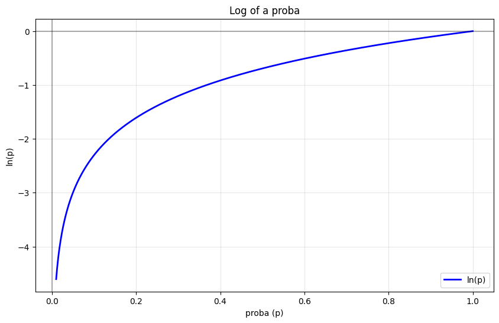

```python
x = np.linspace(0.01, 1, 1000)  # 0 < p <= 1
y = np.log(x)

plt.figure(figsize=(10, 6))
plt.plot(x, y, 'b-', linewidth=2, label='ln(p)')
plt.grid(True, alpha=0.3)

plt.title('Log of a proba')
plt.xlabel('proba (p)')
plt.ylabel('ln(p)')
plt.legend()

plt.axhline(y=0, color='k', linestyle='-', alpha=0.3)
plt.axvline(x=0, color='k', linestyle='-', alpha=0.3)

plt.show()
```

Why work with logs?

$log(a*b*c) = log(a) + log(b) + log(c)$

```python
log_likelihood: float = 0.0
count: int = 0

for w in ['robin']:
    # add special characters
    chs = ['.'] + list(w) + ['.']
    for ch1, ch2 in zip(chs, chs[1:]):
        ix1 = stoi[ch1]
        ix2 = stoi[ch2]
        prob = P[ix1, ix2]
        logprob = torch.log(prob)
        log_likelihood += logprob
        count += 1
        print(f'{ch1}, {ch2} | prob: {prob:.4f} | logprob: {logprob:.4f}')

print(f'\n')
print(f'{log_likelihood=}')
negative_log_likelihood = -log_likelihood
print(f'{negative_log_likelihood=}')
avg_neg_log_likelihood = negative_log_likelihood / count
print(f'{avg_neg_log_likelihood=}')
```

```
., r | prob: 0.0512 | logprob: -2.9727
r, o | prob: 0.0684 | logprob: -2.6820
o, b | prob: 0.0176 | logprob: -4.0373
b, i | prob: 0.0820 | logprob: -2.5005
i, n | prob: 0.1201 | logprob: -2.1194
n, . | prob: 0.3690 | logprob: -0.9969


log_likelihood=tensor(-15.3088)
negative_log_likelihood=tensor(15.3088)
avg_neg_log_likelihood=tensor(2.5515)
```

```python
# we add 1 to N to avoid numerical instabilities
# e.g., "robinqz" -> qz have 0.0000% proba of being seen together -> log(0) = infinity
# infinite loss problem
P = (N + 1).float()
P /= P.sum(dim=1, keepdim=True)
```

## Neural Network Approach

### Create Training set of all the bigrams

```python
# training set of bigrams (x, y)
xs, ys = [], []

for w in words[:1]:
    # add special characters
    chs = ['.'] + list(w) + ['.']
    for ch1, ch2 in zip(chs, chs[1:]):
        ix1 = stoi[ch1]
        ix2 = stoi[ch2]
        print(ch1, ch2)
        xs.append(ix1)
        ys.append(ix2)

# convert to tensor
xs = torch.tensor(xs)
ys = torch.tensor(ys)
```

```
. e
e m
m m
m a
a .
```

```python
xs
```

```
tensor([ 0,  5, 13, 13,  1])
```

```python
ys
```

```
tensor([ 5, 13, 13,  1,  0])
```

## Using a neural network

```python
import torch.nn.functional as F
```

```python
xenc = F.one_hot(xs, num_classes=27).float()
xenc
```

```
tensor([[1., 0., 0., 0., 0., 0., 0., 0., 0., 0., 0., 0., 0., 0., 0., 0., 0., 0.,
         0., 0., 0., 0., 0., 0., 0., 0., 0.],
        [0., 0., 0., 0., 0., 1., 0., 0., 0., 0., 0., 0., 0., 0., 0., 0., 0., 0.,
         0., 0., 0., 0., 0., 0., 0., 0., 0.],
        [0., 0., 0., 0., 0., 0., 0., 0., 0., 0., 0., 0., 0., 1., 0., 0., 0., 0.,
         0., 0., 0., 0., 0., 0., 0., 0., 0.],
        [0., 0., 0., 0., 0., 0., 0., 0., 0., 0., 0., 0., 0., 1., 0., 0., 0., 0.,
         0., 0., 0., 0., 0., 0., 0., 0., 0.],
        [0., 1., 0., 0., 0., 0., 0., 0., 0., 0., 0., 0., 0., 0., 0., 0., 0., 0.,
         0., 0., 0., 0., 0., 0., 0., 0., 0.]])
```

```python
xenc.shape
```

```
torch.Size([5, 27])
```

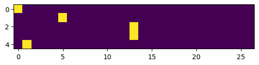

```python
plt.imshow(xenc)
```

```python
xenc.dtype
```

```
torch.float32
```

### Create a Neuron

```python
W = torch.randn((27, 27))
```

```python
# shape (5,27) @ (27, 27) -> (5, 27)
xenc @ W
```

```
tensor([[-0.3365,  1.6438, -1.0196,  0.5436,  0.4487, -0.5271,  1.0737, -0.4626,
         -0.8865, -0.6765, -0.4411, -0.7287,  0.3023, -1.1786, -2.7243, -0.9519,
         -1.2971,  1.6003, -0.2896, -1.4002,  2.3688,  1.8982,  1.7205,  0.9187,
          2.2770,  0.9126, -1.2382],
        [-0.2035, -0.4077, -1.6484, -0.9549,  1.0461,  1.1760,  0.8952, -0.9203,
         -1.8538, -0.4402, -0.0175, -0.1981, -0.9934,  0.2530,  0.2201,  1.6807,
          1.6661,  1.0816,  0.3878,  1.2953, -1.7772,  0.1015,  0.9125, -1.6133,
          1.6094, -1.3716, -0.1570],
        [-0.0271, -1.2893,  0.0381, -1.3023,  0.0266, -0.9651, -0.4167,  0.7901,
          0.1990, -2.7345,  1.1318, -0.3316, -0.9463, -0.6228,  1.0862, -0.4559,
         -1.3538, -0.5680, -1.5638, -0.1075, -0.2358, -0.1953,  1.4326,  0.4432,
          1.3822, -1.3489, -0.0109],
        [-0.0271, -1.2893,  0.0381, -1.3023,  0.0266, -0.9651, -0.4167,  0.7901,
          0.1990, -2.7345,  1.1318, -0.3316, -0.9463, -0.6228,  1.0862, -0.4559,
         -1.3538, -0.5680, -1.5638, -0.1075, -0.2358, -0.1953,  1.4326,  0.4432,
          1.3822, -1.3489, -0.0109],
        [ 1.6065,  1.7761,  0.8222, -0.6929, -1.2994, -0.2216,  0.0174,  0.3109,
         -2.0781,  0.0322,  2.0192,  0.1921,  0.1345, -0.5113,  1.2016,  1.6149,
         -1.0601, -0.2085, -2.0671, -0.1767, -0.2421, -0.9449, -0.5251, -0.6209,
         -0.2541, -1.2890,  0.0409]])
```

```python
# 4 row, 14th column of the MM operation
mm1 = (xenc @ W)[3, 13]
```

```python
xenc[3]
```

```
tensor([0., 0., 0., 0., 0., 0., 0., 0., 0., 0., 0., 0., 0., 1., 0., 0., 0., 0.,
        0., 0., 0., 0., 0., 0., 0., 0., 0.])
```

```python
W[:, 13]
```

```
tensor([-1.1786, -0.5113, -1.7010,  0.6913,  0.8927,  0.2530,  1.3695, -0.0271,
         2.3251, -1.0431,  0.8616, -0.0255,  0.1795, -0.6228,  1.3033,  2.3293,
         0.1389, -0.3265, -2.1949, -1.1237,  0.1451,  0.1804, -0.6386, -1.5707,
        -1.4227, -1.0581,  0.9946])
```

```python
mm2 = (xenc[3] * W[:, 13]).sum()
```

```python
assert mm1 == mm2
```

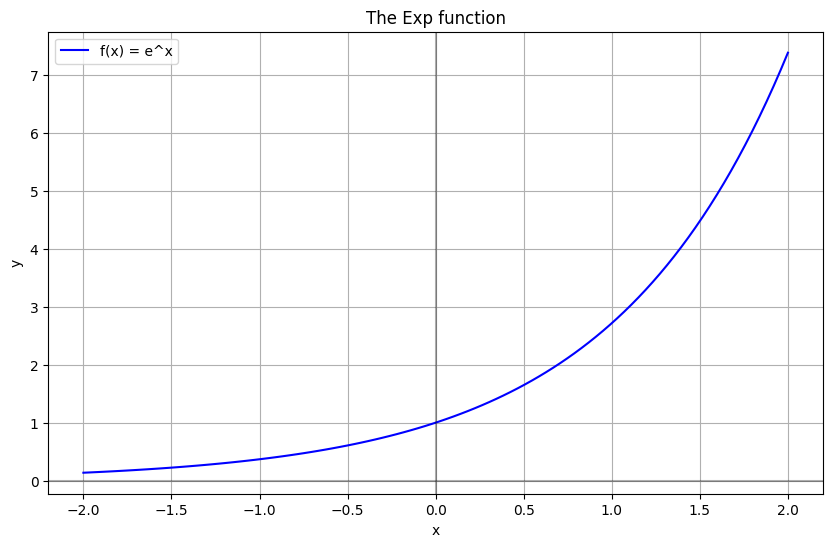

```python
import numpy as np
import matplotlib.pyplot as plt

x = np.linspace(-2, 2, 100)

y = np.exp(x)

plt.figure(figsize=(10, 6))
plt.plot(x, y, 'b-', label='f(x) = e^x')
plt.grid(True)
plt.xlabel('x')
plt.ylabel('y')
plt.title('The Exp function')
plt.legend()

plt.axhline(y=0, color='k', linestyle='-', alpha=0.3)
plt.axvline(x=0, color='k', linestyle='-', alpha=0.3)

plt.show()
```

```python
(xenc @ W).exp()
```

```
tensor([[ 0.7143,  5.1748,  0.3607,  1.7221,  1.5663,  0.5903,  2.9263,  0.6296,
          0.4121,  0.5084,  0.6434,  0.4826,  1.3530,  0.3077,  0.0656,  0.3860,
          0.2733,  4.9543,  0.7486,  0.2466, 10.6845,  6.6741,  5.5872,  2.5060,
          9.7470,  2.4908,  0.2899],
        [ 0.8158,  0.6652,  0.1924,  0.3849,  2.8466,  3.2412,  2.4478,  0.3984,
          0.1566,  0.6439,  0.9826,  0.8203,  0.3703,  1.2879,  1.2463,  5.3692,
          5.2916,  2.9493,  1.4738,  3.6522,  0.1691,  1.1068,  2.4904,  0.1992,
          4.9997,  0.2537,  0.8547],
        [ 0.9733,  0.2755,  1.0388,  0.2719,  1.0269,  0.3810,  0.6592,  2.2037,
          1.2201,  0.0649,  3.1013,  0.7178,  0.3882,  0.5364,  2.9628,  0.6339,
          0.2583,  0.5667,  0.2093,  0.8981,  0.7899,  0.8226,  4.1894,  1.5577,
          3.9836,  0.2595,  0.9892],
        [ 0.9733,  0.2755,  1.0388,  0.2719,  1.0269,  0.3810,  0.6592,  2.2037,
          1.2201,  0.0649,  3.1013,  0.7178,  0.3882,  0.5364,  2.9628,  0.6339,
          0.2583,  0.5667,  0.2093,  0.8981,  0.7899,  0.8226,  4.1894,  1.5577,
          3.9836,  0.2595,  0.9892],
        [ 4.9856,  5.9068,  2.2754,  0.5001,  0.2727,  0.8012,  1.0176,  1.3647,
          0.1252,  1.0328,  7.5324,  1.2118,  1.1440,  0.5997,  3.3254,  5.0274,
          0.3464,  0.8118,  0.1266,  0.8380,  0.7850,  0.3887,  0.5915,  0.5375,
          0.7756,  0.2756,  1.0417]])
```

```python
logits = xenc @ W #log-counts
```

```python
counts = logits.exp() # equivalent to the N matrix
```

```python
# soft argmax
probs = counts / counts.sum(dim=1, keepdims=True)
```

```python
probs[0].sum()
```

```
tensor(1.)
```

```python
probs[0].shape
```

```
torch.Size([27])
```

```python
nlls = torch.zeros(5)
for i in range(5):
  # i-th bigram:
  x = xs[i].item() # input character index
  y = ys[i].item() # label character index
  print('--------')
  print(f'bigram example {i+1}: {itos[x]}{itos[y]} (indexes {x},{y})')
  print('input to the neural net:', x)
  print('output probabilities from the neural net:', probs[i])
  print('label (actual next character):', y)
  p = probs[i, y]
  print('probability assigned by the net to the the correct character:', p.item())
  logp = torch.log(p)
  print('log likelihood:', logp.item())
  nll = -logp
  print('negative log likelihood:', nll.item())
  nlls[i] = nll

print('=========')
print('average negative log likelihood, i.e. loss =', nlls.mean().item())
```

```
--------
bigram example 1: .e (indexes 0,5)
input to the neural net: 0
output probabilities from the neural net: tensor([0.0115, 0.0834, 0.0058, 0.0278, 0.0252, 0.0095, 0.0472, 0.0101, 0.0066,
        0.0082, 0.0104, 0.0078, 0.0218, 0.0050, 0.0011, 0.0062, 0.0044, 0.0798,
        0.0121, 0.0040, 0.1722, 0.1076, 0.0900, 0.0404, 0.1571, 0.0401, 0.0047])
label (actual next character): 5
probability assigned by the net to the the correct character: 0.009514318779110909
log likelihood: -4.654957294464111
negative log likelihood: 4.654957294464111
--------
bigram example 2: em (indexes 5,13)
input to the neural net: 5
output probabilities from the neural net: tensor([0.0180, 0.0147, 0.0042, 0.0085, 0.0628, 0.0715, 0.0540, 0.0088, 0.0035,
        0.0142, 0.0217, 0.0181, 0.0082, 0.0284, 0.0275, 0.1185, 0.1168, 0.0651,
        0.0325, 0.0806, 0.0037, 0.0244, 0.0550, 0.0044, 0.1103, 0.0056, 0.0189])
label (actual next character): 13
probability assigned by the net to the the correct character: 0.028424318879842758
log likelihood: -3.5605101585388184
negative log likelihood: 3.5605101585388184
--------
bigram example 3: mm (indexes 13,13)
input to the neural net: 13
output probabilities from the neural net: tensor([0.0314, 0.0089, 0.0335, 0.0088, 0.0331, 0.0123, 0.0213, 0.0711, 0.0394,
        0.0021, 0.1001, 0.0232, 0.0125, 0.0173, 0.0956, 0.0205, 0.0083, 0.0183,
        0.0068, 0.0290, 0.0255, 0.0266, 0.1352, 0.0503, 0.1286, 0.0084, 0.0319])
label (actual next character): 13
probability assigned by the net to the the correct character: 0.01731523498892784
log likelihood: -4.056168556213379
negative log likelihood: 4.056168556213379
--------
bigram example 4: ma (indexes 13,1)
input to the neural net: 13
output probabilities from the neural net: tensor([0.0314, 0.0089, 0.0335, 0.0088, 0.0331, 0.0123, 0.0213, 0.0711, 0.0394,
        0.0021, 0.1001, 0.0232, 0.0125, 0.0173, 0.0956, 0.0205, 0.0083, 0.0183,
        0.0068, 0.0290, 0.0255, 0.0266, 0.1352, 0.0503, 0.1286, 0.0084, 0.0319])
label (actual next character): 1
probability assigned by the net to the the correct character: 0.008891808800399303
log likelihood: -4.722624778747559
negative log likelihood: 4.722624778747559
--------
bigram example 5: a. (indexes 1,0)
input to the neural net: 1
output probabilities from the neural net: tensor([0.1142, 0.1353, 0.0521, 0.0115, 0.0062, 0.0184, 0.0233, 0.0313, 0.0029,
        0.0237, 0.1726, 0.0278, 0.0262, 0.0137, 0.0762, 0.1152, 0.0079, 0.0186,
        0.0029, 0.0192, 0.0180, 0.0089, 0.0136, 0.0123, 0.0178, 0.0063, 0.0239])
label (actual next character): 0
probability assigned by the net to the the correct character: 0.11424023658037186
log likelihood: -2.1694517135620117
negative log likelihood: 2.1694517135620117
=========
average negative log likelihood, i.e. loss = 3.832742214202881
```

```python
xs
```

```
tensor([ 0,  5, 13, 13,  1])
```

```python
ys
```

```
tensor([ 5, 13, 13,  1,  0])
```

```python
g = torch.Generator().manual_seed(2147483647)
W = torch.randn((27, 27), generator=g, requires_grad=True)
```

```python
xenc = F.one_hot(xs, num_classes=27).float()
logits = xenc @ W
counts = logits.exp()
probs = counts / counts.sum(dim=1, keepdims=True)
```

```python
probs.shape
```

```
torch.Size([5, 27])
```

### Inspect model's predictions

```python
# Inspect the predicted probability for the 'true' class (i.e. ys)
probs[0, 5], probs[1, 13], probs[2, 13], probs[3, 1], probs[4, 0]
```

```
(tensor(0.0123),
 tensor(0.0181),
 tensor(0.0267),
 tensor(0.0737),
 tensor(0.0150))
```

```python
# More efficient way to acces the proba
# first argument gives the rows we want, second argument gives the columns
probs[torch.arange(5), ys]
```

```
tensor([0.0123, 0.0181, 0.0267, 0.0737, 0.0150])
```

### Negative Log likelihood as the loss function

```python
loss = -probs[torch.arange(5), ys].log().mean()
loss
```

```
tensor(3.7693)
```

```python
# forward pass
xenc = F.one_hot(xs, num_classes=27).float()
logits = xenc @ W
counts = logits.exp()
probs = counts / counts.sum(dim=1, keepdims=True)
loss = -probs[torch.arange(5), ys].log().mean()
```

```python
# backward pass
W.grad = None # set the gradient to zero
loss.backward()
```

[output not shown]

```python
loss.item()
```

```
3.7693049907684326
```

```python
W.grad
```

```
tensor([[ 0.0121,  0.0020,  0.0025,  0.0008,  0.0034, -0.1975,  0.0005,  0.0046,
          0.0027,  0.0063,  0.0016,  0.0056,  0.0018,  0.0016,  0.0100,  0.0476,
          0.0121,  0.0005,  0.0050,  0.0011,  0.0068,  0.0022,  0.0006,  0.0040,
          0.0024,  0.0307,  0.0292],
        [-0.1970,  0.0017,  0.0079,  0.0020,  0.0121,  0.0062,  0.0217,  0.0026,
          0.0025,  0.0010,  0.0205,  0.0017,  0.0198,  0.0022,  0.0046,  0.0041,
          0.0082,  0.0016,  0.0180,  0.0106,  0.0093,  0.0062,  0.0010,  0.0066,
          0.0131,  0.0101,  0.0018],
        [ 0.0000,  0.0000,  0.0000,  0.0000,  0.0000,  0.0000,  0.0000,  0.0000,
          0.0000,  0.0000,  0.0000,  0.0000,  0.0000,  0.0000,  0.0000,  0.0000,
          0.0000,  0.0000,  0.0000,  0.0000,  0.0000,  0.0000,  0.0000,  0.0000,
          0.0000,  0.0000,  0.0000],
        [ 0.0000,  0.0000,  0.0000,  0.0000,  0.0000,  0.0000,  0.0000,  0.0000,
          0.0000,  0.0000,  0.0000,  0.0000,  0.0000,  0.0000,  0.0000,  0.0000,
          0.0000,  0.0000,  0.0000,  0.0000,  0.0000,  0.0000,  0.0000,  0.0000,
          0.0000,  0.0000,  0.0000],
        [ 0.0000,  0.0000,  0.0000,  0.0000,  0.0000,  0.0000,  0.0000,  0.0000,
          0.0000,  0.0000,  0.0000,  0.0000,  0.0000,  0.0000,  0.0000,  0.0000,
          0.0000,  0.0000,  0.0000,  0.0000,  0.0000,  0.0000,  0.0000,  0.0000,
          0.0000,  0.0000,  0.0000],
        [ 0.0058,  0.0159,  0.0050,  0.0104,  0.0398,  0.0058,  0.0019,  0.0067,
          0.0019,  0.0060,  0.0140,  0.0046,  0.0023, -0.1964,  0.0022,  0.0063,
          0.0058,  0.0009,  0.0183,  0.0043,  0.0097,  0.0060,  0.0100,  0.0005,
          0.0024,  0.0004,  0.0094],
        [ 0.0000,  0.0000,  0.0000,  0.0000,  0.0000,  0.0000,  0.0000,  0.0000,
          0.0000,  0.0000,  0.0000,  0.0000,  0.0000,  0.0000,  0.0000,  0.0000,
          0.0000,  0.0000,  0.0000,  0.0000,  0.0000,  0.0000,  0.0000,  0.0000,
          0.0000,  0.0000,  0.0000],
        [ 0.0000,  0.0000,  0.0000,  0.0000,  0.0000,  0.0000,  0.0000,  0.0000,
          0.0000,  0.0000,  0.0000,  0.0000,  0.0000,  0.0000,  0.0000,  0.0000,
          0.0000,  0.0000,  0.0000,  0.0000,  0.0000,  0.0000,  0.0000,  0.0000,
          0.0000,  0.0000,  0.0000],
        [ 0.0000,  0.0000,  0.0000,  0.0000,  0.0000,  0.0000,  0.0000,  0.0000,
          0.0000,  0.0000,  0.0000,  0.0000,  0.0000,  0.0000,  0.0000,  0.0000,
          0.0000,  0.0000,  0.0000,  0.0000,  0.0000,  0.0000,  0.0000,  0.0000,
          0.0000,  0.0000,  0.0000],
        [ 0.0000,  0.0000,  0.0000,  0.0000,  0.0000,  0.0000,  0.0000,  0.0000,
          0.0000,  0.0000,  0.0000,  0.0000,  0.0000,  0.0000,  0.0000,  0.0000,
          0.0000,  0.0000,  0.0000,  0.0000,  0.0000,  0.0000,  0.0000,  0.0000,
          0.0000,  0.0000,  0.0000],
```

[output cut: 53 more lines]

```
          0.0000,  0.0000,  0.0000,  0.0000,  0.0000,  0.0000,  0.0000,  0.0000,
          0.0000,  0.0000,  0.0000,  0.0000,  0.0000,  0.0000,  0.0000,  0.0000,
          0.0000,  0.0000,  0.0000],
        [ 0.0000,  0.0000,  0.0000,  0.0000,  0.0000,  0.0000,  0.0000,  0.0000,
          0.0000,  0.0000,  0.0000,  0.0000,  0.0000,  0.0000,  0.0000,  0.0000,
          0.0000,  0.0000,  0.0000,  0.0000,  0.0000,  0.0000,  0.0000,  0.0000,
          0.0000,  0.0000,  0.0000],
        [ 0.0000,  0.0000,  0.0000,  0.0000,  0.0000,  0.0000,  0.0000,  0.0000,
          0.0000,  0.0000,  0.0000,  0.0000,  0.0000,  0.0000,  0.0000,  0.0000,
          0.0000,  0.0000,  0.0000,  0.0000,  0.0000,  0.0000,  0.0000,  0.0000,
          0.0000,  0.0000,  0.0000],
        [ 0.0000,  0.0000,  0.0000,  0.0000,  0.0000,  0.0000,  0.0000,  0.0000,
          0.0000,  0.0000,  0.0000,  0.0000,  0.0000,  0.0000,  0.0000,  0.0000,
          0.0000,  0.0000,  0.0000,  0.0000,  0.0000,  0.0000,  0.0000,  0.0000,
          0.0000,  0.0000,  0.0000]])
```

```python
# update weights
W.data += -0.1 * W.grad
```

```python
loss.item()
```

```
3.7693049907684326
```

## Training loop

```python
# create the dataset
xs, ys = [], []
for w in words:
  chs = ['.'] + list(w) + ['.']
  for ch1, ch2 in zip(chs, chs[1:]):
    ix1 = stoi[ch1]
    ix2 = stoi[ch2]
    xs.append(ix1)
    ys.append(ix2)
xs = torch.tensor(xs)
ys = torch.tensor(ys)
num = xs.nelement()
print('number of examples: ', num)

# initialize the 'network'
g = torch.Generator().manual_seed(2147483647)
W = torch.randn((27, 27), generator=g, requires_grad=True)
```

```
number of examples:  228146
```

```python
# gradient descent
debug: bool = False

for k in range(1000):
  # forward pass
  xenc = F.one_hot(xs, num_classes=27).float() # input to the network: one-hot encoding
  logits = xenc @ W # predict log-counts
  counts = logits.exp() # counts, equivalent to N
  probs = counts / counts.sum(1, keepdims=True) # probabilities for next character
  loss = -probs[torch.arange(num), ys].log().mean() + 0.01*(W**2).mean() # add regularization
  if debug: print(loss.item())

  # backward pass
  W.grad = None # set to zero the gradient
  loss.backward()

  # update
  W.data += -50 * W.grad
```

[output not shown]

[output cut: 945 more lines]

[output not shown]

```python
# finally, sample from the 'neural net' model
g = torch.Generator().manual_seed(2147483647)

for i in range(5):

  out = []
  ix = 0
  while True:

    # ----------
    # BEFORE:
    #p = P[ix]
    # ----------
    # NOW:
    xenc = F.one_hot(torch.tensor([ix]), num_classes=27).float()
    logits = xenc @ W # predict log-counts
    counts = logits.exp() # counts, equivalent to N
    p = counts / counts.sum(1, keepdims=True) # probabilities for next character
    # ----------

    ix = torch.multinomial(p, num_samples=1, replacement=True, generator=g).item()
    out.append(itos[ix])
    if ix == 0:
      break
  print(''.join(out))
```

```
junide.
janasah.
p.
cfay.
a.
```